# Dashboard: Effects

Tornado plots

Carlos Guío

2021-12-14

## Read and prepare Q1 and Q2 datasets

Q1 and Q2 datasets are loaded by sourcing the `Prepare_Effects_Tornado.R`script.

Q1 datasets were designed to answer questions such as:

- Who adopted/disadopted practices and why?
- Who accessed/used climate information services?

Q2 datasets were designed to answer questions such as:

- How does the implementation of CSA practices affect food security, vulnerability to climate shocks, gender and income?
- How does the use of CIS affect changes in animal and crop management?

### Visaulization choice: tornado plot with `ggplot` (CRAN)

In the next chunk you will find a function that allows to plot the relationship between practices (or services) and perceived socio-economic effects (indicators) at each site. The information is at the farmer level.

```r
f_tornado <- function(dataset = effect_dat, CSA_category, outcome, indic, location, year_1, year_2){

  library(tidyverse)
  library(ggplot2)


   # Error messages
  if (!CSA_category %in% c("Practices", "Services"))
    stop("use either Practices or Services as CSA_category")

  if (!outcome %in% dataset$outcome_category)
    stop("assign a valid outcome category")

  if (!indic %in% dataset$indicator)
    stop("assign a valid indicator")

  years <- dataset %>% ungroup() %>%
    filter(site == location, option == CSA_category, outcome_category == outcome,
         indicator == indic) %>%
    select(year) %>%
  distinct()

  if (!any(range(years) %in% seq(year_1, year_2, by=1)))
    stop("assign a valid year interval to the surveyed site")

  if (!location %in% dataset$site | length(location) >1)
    stop("assign a single valid site name as location")


# Filter data according to arguments
  tornado_dat <- dataset %>%
  filter(option == CSA_category,
         outcome_category == outcome,
         indicator == indic,
         site == location) %>%
  filter(!is.na(practice_type)) %>%
  mutate(percentage_lab = case_when(percentage < 2 ~ "",
                                    TRUE ~ as.character(paste0(percentage, "%"))),
         gender_legend = paste0(gender," (n: ",n_site,")"))


  # Plot
  ggplot(tornado_dat) +
  geom_col(aes(x = factor(practice_type, levels = rev(levels(factor(practice_type)))),
               y = ifelse(gender == "Male", percentage, -percentage),
               fill = gender)) +
  geom_text(aes(x = practice_type,
                y = ifelse(gender == "Male", percentage + 8, -percentage -8),
                label = percentage_lab),
            size = 2,
            color = "#5D5C58",
            fontface = "bold") +
  scale_alpha(range = c(0.5, 1))+
  scale_fill_manual(values = c("#FFC107", "#a9713d")) +
  scale_y_continuous(limits = c(-max(tornado_dat$percentage) -10, max(tornado_dat$percentage) +10))+
  facet_grid(indicator ~ site + year )+
  coord_flip() +
  guides(alpha = "none")+labs(caption = "*Empty spaces are due to practices or services that were not assessed at the selected site and year.")+
  theme_minimal(base_family = "Calibri")+
  theme(panel.grid = element_blank(),
        # Optional color brackgrouns as in dashboard
        #panel.background = element_rect(fill = "#faf9f5", color = "#ECEBE7" ),
        #plot.background = element_rect(fill = "#faf9f5",  color = "#faf9f5"),
        strip.background = element_rect(fill = "#ECEBE7", color = "#ECEBE7"),
        strip.text.x = element_text(margin = margin(1,0,1,0, "mm"), size = 11, color = "#5D5C58"),
        strip.text.y = element_text(margin = margin(0,2,0,2, "mm"), size = 11, color = "#5D5C58"),
        legend.title = element_blank(),
        legend.justification = "left",
        legend.position = "bottom",
        legend.key.size = unit(1.5, 'lines'),
        legend.text = element_text(size = 9, color = "#5D5C58"),
        plot.caption = element_text(size = 6, hjust = 1, margin = margin(5,0,2,0, "mm")),
        axis.title = element_blank(),
        axis.text.y = element_text(color = "#B8B7B3", size = 9),
        axis.text.x = element_blank(),
        plot.margin=unit(c(5,5,5,5), "mm"),
        panel.spacing = unit(1.5, "lines"))

}
```

#### Use the function to create a tornado plot

The argumens of the function take in values similar to the drop down menus used in the PBI-dashboard.

To export it, first store it as an object.

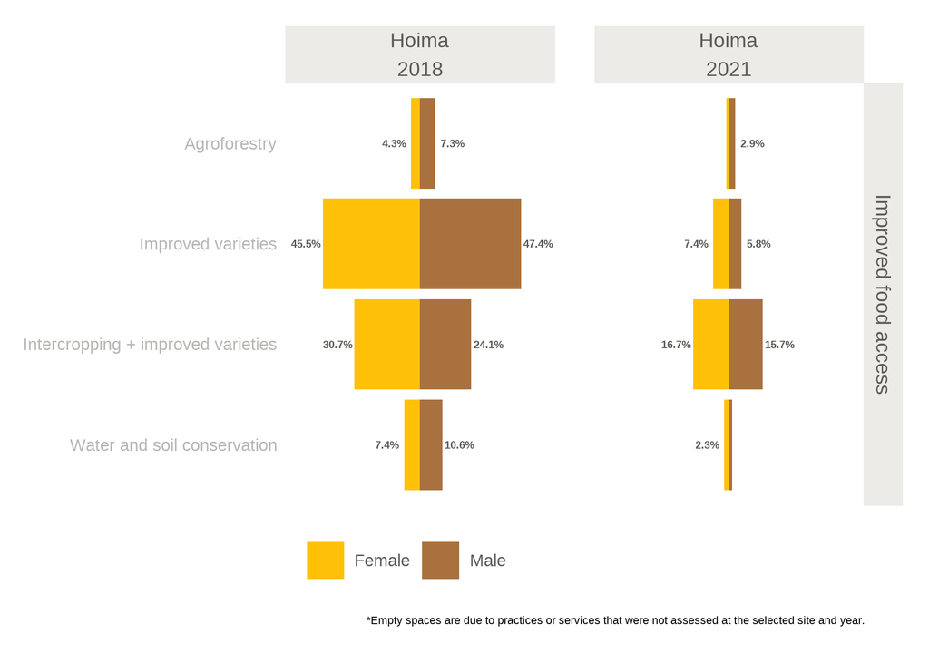

```r
p_tornado <- f_tornado(CSA_category = "Practices", outcome = "Food security", indic = "Improved food access", location = "Hoima", year_1 = 2018, year_2 = 2021)

p_tornado
```

```r
# Export
#ggsave(file = "p_barplot.png", plot = p_barplot, device = "png", type = "cairo", path = "Input a path from your PC, dpi = 300, width = 9.5, height = 5)
```